# Risk Factor Analysis

## Outcome Variable

**Outcome Variable:** ever_stunted

## Predictor Variables

**Intervention Variable:** tr

**Adjustment Set:**

unadjusted

## Stratifying Variables

The analysis was stratified on these variable(s):

- agecat
- studyid
- country
- intXenstunt

## Data Summary

| agecat | studyid | country | intXenstunt | ever_stunted | n_cell | n |
| --- | --- | --- | --- | --- | --- | --- |
| 0-6 months | iLiNS_DYADM_LNS | MALAWI | 0_0-6 months | 0 | 31 | 33 |
| 0-6 months | iLiNS_DYADM_LNS | MALAWI | 0_0-6 months | 1 | 2 | 33 |
| 0-6 months | iLiNS_DYADM_LNS | MALAWI | 1_0-6 months | 0 | 2 | 10 |
| 0-6 months | iLiNS_DYADM_LNS | MALAWI | 1_0-6 months | 1 | 8 | 10 |
| 0-6 months | ki1000107-Serrinha-VitA | BRAZIL | 0_0-6 months | 0 | 9 | 9 |
| 0-6 months | ki1000107-Serrinha-VitA | BRAZIL | 0_0-6 months | 1 | 0 | 9 |
| 0-6 months | ki1000107-Serrinha-VitA | BRAZIL | 1_0-6 months | 0 | 0 | 1 |
| 0-6 months | ki1000107-Serrinha-VitA | BRAZIL | 1_0-6 months | 1 | 1 | 1 |
| 0-6 months | ki1000110-WASH-Bangladesh | BANGLADESH | 0_0-6 months | 0 | 209 | 209 |
| 0-6 months | ki1000110-WASH-Bangladesh | BANGLADESH | 0_0-6 months | 1 | 0 | 209 |
| 0-6 months | ki1000110-WASH-Bangladesh | BANGLADESH | 1_0-6 months | 0 | 0 | 23 |
| 0-6 months | ki1000110-WASH-Bangladesh | BANGLADESH | 1_0-6 months | 1 | 23 | 23 |
| 0-6 months | ki1000111-WASH-Kenya | KENYA | 0_0-6 months | 0 | 85 | 85 |
| 0-6 months | ki1000111-WASH-Kenya | KENYA | 0_0-6 months | 1 | 0 | 85 |
| 0-6 months | ki1000111-WASH-Kenya | KENYA | 1_0-6 months | 0 | 0 | 7 |
| 0-6 months | ki1000111-WASH-Kenya | KENYA | 1_0-6 months | 1 | 7 | 7 |
| 0-6 months | ki1000125-AgaKhanUniv | PAKISTAN | 0_0-6 months | 0 | 167 | 205 |
| 0-6 months | ki1000125-AgaKhanUniv | PAKISTAN | 0_0-6 months | 1 | 38 | 205 |
| 0-6 months | ki1000125-AgaKhanUniv | PAKISTAN | 1_0-6 months | 0 | 48 | 87 |
| 0-6 months | ki1000125-AgaKhanUniv | PAKISTAN | 1_0-6 months | 1 | 39 | 87 |
| 0-6 months | ki1000304-EU | INDIA | 0_0-6 months | 0 | 7 | 7 |
| 0-6 months | ki1000304-EU | INDIA | 0_0-6 months | 1 | 0 | 7 |
| 0-6 months | ki1000304-EU | INDIA | 1_0-6 months | 0 | 0 | 7 |
| 0-6 months | ki1000304-EU | INDIA | 1_0-6 months | 1 | 7 | 7 |
| 0-6 months | ki1000304-VITAMIN-A | INDIA | 0_0-6 months | 0 | 209 | 239 |
| 0-6 months | ki1000304-VITAMIN-A | INDIA | 0_0-6 months | 1 | 30 | 239 |
| 0-6 months | ki1000304-VITAMIN-A | INDIA | 1_0-6 months | 0 | 18 | 95 |
| 0-6 months | ki1000304-VITAMIN-A | INDIA | 1_0-6 months | 1 | 77 | 95 |
| 0-6 months | ki1000304-Vitamin-B12 | INDIA | 0_0-6 months | 0 | 1 | 1 |
| 0-6 months | ki1000304-Vitamin-B12 | INDIA | 0_0-6 months | 1 | 0 | 1 |

[output cut: 156 more lines]

The following strata were considered:

- agecat: 0-6 months, studyid: iLiNS_DYADM_LNS, country: MALAWI, intXenstunt: 0_0-6 months
- agecat: 0-6 months, studyid: iLiNS_DYADM_LNS, country: MALAWI, intXenstunt: 1_0-6 months
- agecat: 0-6 months, studyid: ki1000107-Serrinha-VitA, country: BRAZIL, intXenstunt: 0_0-6 months
- agecat: 0-6 months, studyid: ki1000107-Serrinha-VitA, country: BRAZIL, intXenstunt: 1_0-6 months
- agecat: 0-6 months, studyid: ki1000110-WASH-Bangladesh, country: BANGLADESH, intXenstunt: 0_0-6 months
- agecat: 0-6 months, studyid: ki1000110-WASH-Bangladesh, country: BANGLADESH, intXenstunt: 1_0-6 months
- agecat: 0-6 months, studyid: ki1000111-WASH-Kenya, country: KENYA, intXenstunt: 0_0-6 months
- agecat: 0-6 months, studyid: ki1000111-WASH-Kenya, country: KENYA, intXenstunt: 1_0-6 months
- agecat: 0-6 months, studyid: ki1000125-AgaKhanUniv, country: PAKISTAN, intXenstunt: 0_0-6 months
- agecat: 0-6 months, studyid: ki1000125-AgaKhanUniv, country: PAKISTAN, intXenstunt: 1_0-6 months
- agecat: 0-6 months, studyid: ki1000304-EU, country: INDIA, intXenstunt: 0_0-6 months
- agecat: 0-6 months, studyid: ki1000304-EU, country: INDIA, intXenstunt: 1_0-6 months
- agecat: 0-6 months, studyid: ki1000304-VITAMIN-A, country: INDIA, intXenstunt: 0_0-6 months
- agecat: 0-6 months, studyid: ki1000304-VITAMIN-A, country: INDIA, intXenstunt: 1_0-6 months
- agecat: 0-6 months, studyid: ki1000304-Vitamin-B12, country: INDIA, intXenstunt: 0_0-6 months
- agecat: 0-6 months, studyid: ki1000304-ZnMort, country: INDIA, intXenstunt: 0_0-6 months
- agecat: 0-6 months, studyid: ki1000304-ZnMort, country: INDIA, intXenstunt: 1_0-6 months
- agecat: 0-6 months, studyid: ki1000304b-SAS-CompFeed, country: INDIA, intXenstunt: 0_0-6 months
- agecat: 0-6 months, studyid: ki1000304b-SAS-CompFeed, country: INDIA, intXenstunt: 1_0-6 months
- agecat: 0-6 months, studyid: ki1000304b-SAS-FoodSuppl, country: INDIA, intXenstunt: 0_0-6 months
- agecat: 0-6 months, studyid: ki1000304b-SAS-FoodSuppl, country: INDIA, intXenstunt: 1_0-6 months
- agecat: 0-6 months, studyid: ki1017093b-PROVIDE, country: BANGLADESH, intXenstunt: 0_0-6 months
- agecat: 0-6 months, studyid: ki1017093b-PROVIDE, country: BANGLADESH, intXenstunt: 1_0-6 months
- agecat: 0-6 months, studyid: ki1066203-TanzaniaChild2, country: TANZANIA, UNITED REPUBLIC OF, intXenstunt: 0_0-6 months
- agecat: 0-6 months, studyid: ki1066203-TanzaniaChild2, country: TANZANIA, UNITED REPUBLIC OF, intXenstunt: 1_0-6 months
- agecat: 0-6 months, studyid: ki1112895-Burkina Faso Zn, country: BURKINA FASO, intXenstunt: 0_0-6 months
- agecat: 0-6 months, studyid: ki1112895-Burkina Faso Zn, country: BURKINA FASO, intXenstunt: 1_0-6 months
- agecat: 0-6 months, studyid: ki1112895-Guatemala BSC, country: GUATEMALA, intXenstunt: 0_0-6 months
- agecat: 0-6 months, studyid: ki1112895-Guatemala BSC, country: GUATEMALA, intXenstunt: 1_0-6 months
- agecat: 0-6 months, studyid: ki1119695-PROBIT, country: BELARUS, intXenstunt: 0_0-6 months
- agecat: 0-6 months, studyid: ki1119695-PROBIT, country: BELARUS, intXenstunt: 1_0-6 months
- agecat: 0-6 months, studyid: ki1126311-ZVITAMBO, country: ZIMBABWE, intXenstunt: 0_0-6 months
- agecat: 0-6 months, studyid: ki1126311-ZVITAMBO, country: ZIMBABWE, intXenstunt: 1_0-6 months
- agecat: 0-6 months, studyid: ki1135781-COHORTS, country: GUATEMALA, intXenstunt: 0_0-6 months
- agecat: 0-6 months, studyid: ki1135781-COHORTS, country: GUATEMALA, intXenstunt: 1_0-6 months
- agecat: 0-6 months, studyid: ki1148112-iLiNS-DOSE, country: MALAWI, intXenstunt: 0_0-6 months
- agecat: 0-6 months, studyid: ki1148112-iLiNS-DOSE, country: MALAWI, intXenstunt: 1_0-6 months
- agecat: 0-6 months, studyid: ki1148112-iLiNS-DYAD-M, country: MALAWI, intXenstunt: 0_0-6 months
- agecat: 0-6 months, studyid: ki1148112-iLiNS-DYAD-M, country: MALAWI, intXenstunt: 1_0-6 months
- agecat: 0-6 months, studyid: ki1148112-LCNI-5, country: MALAWI, intXenstunt: 0_0-6 months
- agecat: 0-6 months, studyid: ki1148112-LCNI-5, country: MALAWI, intXenstunt: 1_0-6 months
- agecat: 0-6 months, studyid: kiGH5241-JiVitA-3, country: BANGLADESH, intXenstunt: 0_0-6 months
- agecat: 0-6 months, studyid: kiGH5241-JiVitA-3, country: BANGLADESH, intXenstunt: 1_0-6 months
- agecat: 0-6 months, studyid: kiGH5241-JiVitA-4, country: BANGLADESH, intXenstunt: 0_0-6 months
- agecat: 0-6 months, studyid: kiGH5241-JiVitA-4, country: BANGLADESH, intXenstunt: 1_0-6 months
- agecat: 6-24 months, studyid: iLiNS_DYADM_LNS, country: MALAWI, intXenstunt: 0_6-24 months
- agecat: 6-24 months, studyid: iLiNS_DYADM_LNS, country: MALAWI, intXenstunt: 1_6-24 months
- agecat: 6-24 months, studyid: iLiNS-Zinc_ZvLNS, country: BURKINA FASO, intXenstunt: 0_6-24 months
- agecat: 6-24 months, studyid: iLiNS-Zinc_ZvLNS, country: BURKINA FASO, intXenstunt: 1_6-24 months
- agecat: 6-24 months, studyid: ki1000107-Serrinha-VitA, country: BRAZIL, intXenstunt: 0_6-24 months
- agecat: 6-24 months, studyid: ki1000107-Serrinha-VitA, country: BRAZIL, intXenstunt: 1_6-24 months
- agecat: 6-24 months, studyid: ki1000110-WASH-Bangladesh, country: BANGLADESH, intXenstunt: 0_6-24 months
- agecat: 6-24 months, studyid: ki1000110-WASH-Bangladesh, country: BANGLADESH, intXenstunt: 1_6-24 months
- agecat: 6-24 months, studyid: ki1000111-WASH-Kenya, country: KENYA, intXenstunt: 0_6-24 months
- agecat: 6-24 months, studyid: ki1000111-WASH-Kenya, country: KENYA, intXenstunt: 1_6-24 months
- agecat: 6-24 months, studyid: ki1000125-AgaKhanUniv, country: PAKISTAN, intXenstunt: 0_6-24 months
- agecat: 6-24 months, studyid: ki1000125-AgaKhanUniv, country: PAKISTAN, intXenstunt: 1_6-24 months
- agecat: 6-24 months, studyid: ki1000304-EU, country: INDIA, intXenstunt: 0_6-24 months
- agecat: 6-24 months, studyid: ki1000304-EU, country: INDIA, intXenstunt: 1_6-24 months
- agecat: 6-24 months, studyid: ki1000304-VITAMIN-A, country: INDIA, intXenstunt: 0_6-24 months
- agecat: 6-24 months, studyid: ki1000304-VITAMIN-A, country: INDIA, intXenstunt: 1_6-24 months
- agecat: 6-24 months, studyid: ki1000304-Vitamin-B12, country: INDIA, intXenstunt: 0_6-24 months
- agecat: 6-24 months, studyid: ki1000304-Vitamin-B12, country: INDIA, intXenstunt: 1_6-24 months
- agecat: 6-24 months, studyid: ki1000304-ZnMort, country: INDIA, intXenstunt: 0_6-24 months
- agecat: 6-24 months, studyid: ki1000304-ZnMort, country: INDIA, intXenstunt: 1_6-24 months
- agecat: 6-24 months, studyid: ki1000304b-SAS-CompFeed, country: INDIA, intXenstunt: 0_6-24 months
- agecat: 6-24 months, studyid: ki1000304b-SAS-FoodSuppl, country: INDIA, intXenstunt: 0_6-24 months
- agecat: 6-24 months, studyid: ki1000304b-SAS-FoodSuppl, country: INDIA, intXenstunt: 1_6-24 months
- agecat: 6-24 months, studyid: ki1017093b-PROVIDE, country: BANGLADESH, intXenstunt: 0_6-24 months
- agecat: 6-24 months, studyid: ki1066203-TanzaniaChild2, country: TANZANIA, UNITED REPUBLIC OF, intXenstunt: 0_6-24 months
- agecat: 6-24 months, studyid: ki1066203-TanzaniaChild2, country: TANZANIA, UNITED REPUBLIC OF, intXenstunt: 1_6-24 months
- agecat: 6-24 months, studyid: ki1112895-Burkina Faso Zn, country: BURKINA FASO, intXenstunt: 0_6-24 months
- agecat: 6-24 months, studyid: ki1112895-Burkina Faso Zn, country: BURKINA FASO, intXenstunt: 1_6-24 months
- agecat: 6-24 months, studyid: ki1112895-Guatemala BSC, country: GUATEMALA, intXenstunt: 0_6-24 months
- agecat: 6-24 months, studyid: ki1112895-Guatemala BSC, country: GUATEMALA, intXenstunt: 1_6-24 months
- agecat: 6-24 months, studyid: ki1112895-iLiNS-Zinc, country: BURKINA FASO, intXenstunt: 0_6-24 months
- agecat: 6-24 months, studyid: ki1112895-iLiNS-Zinc, country: BURKINA FASO, intXenstunt: 1_6-24 months
- agecat: 6-24 months, studyid: ki1119695-PROBIT, country: BELARUS, intXenstunt: 0_6-24 months
- agecat: 6-24 months, studyid: ki1119695-PROBIT, country: BELARUS, intXenstunt: 1_6-24 months
- agecat: 6-24 months, studyid: ki1126311-ZVITAMBO, country: ZIMBABWE, intXenstunt: 0_6-24 months
- agecat: 6-24 months, studyid: ki1126311-ZVITAMBO, country: ZIMBABWE, intXenstunt: 1_6-24 months
- agecat: 6-24 months, studyid: ki1135781-COHORTS, country: GUATEMALA, intXenstunt: 0_6-24 months
- agecat: 6-24 months, studyid: ki1135781-COHORTS, country: GUATEMALA, intXenstunt: 1_6-24 months
- agecat: 6-24 months, studyid: ki1148112-iLiNS-DOSE, country: MALAWI, intXenstunt: 0_6-24 months
- agecat: 6-24 months, studyid: ki1148112-iLiNS-DOSE, country: MALAWI, intXenstunt: 1_6-24 months
- agecat: 6-24 months, studyid: ki1148112-iLiNS-DYAD-M, country: MALAWI, intXenstunt: 0_6-24 months
- agecat: 6-24 months, studyid: ki1148112-iLiNS-DYAD-M, country: MALAWI, intXenstunt: 1_6-24 months
- agecat: 6-24 months, studyid: ki1148112-LCNI-5, country: MALAWI, intXenstunt: 0_6-24 months
- agecat: 6-24 months, studyid: ki1148112-LCNI-5, country: MALAWI, intXenstunt: 1_6-24 months
- agecat: 6-24 months, studyid: kiGH5241-JiVitA-3, country: BANGLADESH, intXenstunt: 0_6-24 months
- agecat: 6-24 months, studyid: kiGH5241-JiVitA-3, country: BANGLADESH, intXenstunt: 1_6-24 months
- agecat: 6-24 months, studyid: kiGH5241-JiVitA-4, country: BANGLADESH, intXenstunt: 0_6-24 months
- agecat: 6-24 months, studyid: kiGH5241-JiVitA-4, country: BANGLADESH, intXenstunt: 1_6-24 months

### Dropped Strata

Some strata were dropped due to rare outcomes:

- agecat: 0-6 months, studyid: iLiNS_DYADM_LNS, country: MALAWI, intXenstunt: 0_0-6 months
- agecat: 0-6 months, studyid: iLiNS_DYADM_LNS, country: MALAWI, intXenstunt: 1_0-6 months
- agecat: 0-6 months, studyid: ki1000107-Serrinha-VitA, country: BRAZIL, intXenstunt: 0_0-6 months
- agecat: 0-6 months, studyid: ki1000107-Serrinha-VitA, country: BRAZIL, intXenstunt: 1_0-6 months
- agecat: 0-6 months, studyid: ki1000110-WASH-Bangladesh, country: BANGLADESH, intXenstunt: 0_0-6 months
- agecat: 0-6 months, studyid: ki1000110-WASH-Bangladesh, country: BANGLADESH, intXenstunt: 1_0-6 months
- agecat: 0-6 months, studyid: ki1000111-WASH-Kenya, country: KENYA, intXenstunt: 0_0-6 months
- agecat: 0-6 months, studyid: ki1000111-WASH-Kenya, country: KENYA, intXenstunt: 1_0-6 months
- agecat: 0-6 months, studyid: ki1000304-EU, country: INDIA, intXenstunt: 0_0-6 months
- agecat: 0-6 months, studyid: ki1000304-EU, country: INDIA, intXenstunt: 1_0-6 months
- agecat: 0-6 months, studyid: ki1000304-Vitamin-B12, country: INDIA, intXenstunt: 0_0-6 months
- agecat: 0-6 months, studyid: ki1000304-ZnMort, country: INDIA, intXenstunt: 0_0-6 months
- agecat: 0-6 months, studyid: ki1000304-ZnMort, country: INDIA, intXenstunt: 1_0-6 months
- agecat: 0-6 months, studyid: ki1000304b-SAS-FoodSuppl, country: INDIA, intXenstunt: 0_0-6 months
- agecat: 0-6 months, studyid: ki1000304b-SAS-FoodSuppl, country: INDIA, intXenstunt: 1_0-6 months
- agecat: 0-6 months, studyid: ki1112895-Burkina Faso Zn, country: BURKINA FASO, intXenstunt: 0_0-6 months
- agecat: 0-6 months, studyid: ki1112895-Burkina Faso Zn, country: BURKINA FASO, intXenstunt: 1_0-6 months
- agecat: 0-6 months, studyid: ki1112895-Guatemala BSC, country: GUATEMALA, intXenstunt: 0_0-6 months
- agecat: 0-6 months, studyid: ki1112895-Guatemala BSC, country: GUATEMALA, intXenstunt: 1_0-6 months
- agecat: 0-6 months, studyid: ki1135781-COHORTS, country: GUATEMALA, intXenstunt: 1_0-6 months
- agecat: 0-6 months, studyid: ki1148112-iLiNS-DOSE, country: MALAWI, intXenstunt: 0_0-6 months
- agecat: 0-6 months, studyid: ki1148112-iLiNS-DOSE, country: MALAWI, intXenstunt: 1_0-6 months
- agecat: 0-6 months, studyid: ki1148112-iLiNS-DYAD-M, country: MALAWI, intXenstunt: 0_0-6 months
- agecat: 0-6 months, studyid: ki1148112-iLiNS-DYAD-M, country: MALAWI, intXenstunt: 1_0-6 months
- agecat: 0-6 months, studyid: ki1148112-LCNI-5, country: MALAWI, intXenstunt: 0_0-6 months
- agecat: 0-6 months, studyid: ki1148112-LCNI-5, country: MALAWI, intXenstunt: 1_0-6 months
- agecat: 6-24 months, studyid: iLiNS_DYADM_LNS, country: MALAWI, intXenstunt: 1_6-24 months
- agecat: 6-24 months, studyid: iLiNS-Zinc_ZvLNS, country: BURKINA FASO, intXenstunt: 1_6-24 months
- agecat: 6-24 months, studyid: ki1000107-Serrinha-VitA, country: BRAZIL, intXenstunt: 1_6-24 months
- agecat: 6-24 months, studyid: ki1000110-WASH-Bangladesh, country: BANGLADESH, intXenstunt: 1_6-24 months
- agecat: 6-24 months, studyid: ki1000111-WASH-Kenya, country: KENYA, intXenstunt: 1_6-24 months
- agecat: 6-24 months, studyid: ki1000125-AgaKhanUniv, country: PAKISTAN, intXenstunt: 1_6-24 months
- agecat: 6-24 months, studyid: ki1000304-EU, country: INDIA, intXenstunt: 1_6-24 months
- agecat: 6-24 months, studyid: ki1000304-VITAMIN-A, country: INDIA, intXenstunt: 1_6-24 months
- agecat: 6-24 months, studyid: ki1000304-Vitamin-B12, country: INDIA, intXenstunt: 1_6-24 months
- agecat: 6-24 months, studyid: ki1000304-ZnMort, country: INDIA, intXenstunt: 0_6-24 months
- agecat: 6-24 months, studyid: ki1000304-ZnMort, country: INDIA, intXenstunt: 1_6-24 months
- agecat: 6-24 months, studyid: ki1000304b-SAS-FoodSuppl, country: INDIA, intXenstunt: 1_6-24 months
- agecat: 6-24 months, studyid: ki1066203-TanzaniaChild2, country: TANZANIA, UNITED REPUBLIC OF, intXenstunt: 1_6-24 months
- agecat: 6-24 months, studyid: ki1112895-Burkina Faso Zn, country: BURKINA FASO, intXenstunt: 1_6-24 months
- agecat: 6-24 months, studyid: ki1112895-Guatemala BSC, country: GUATEMALA, intXenstunt: 1_6-24 months
- agecat: 6-24 months, studyid: ki1112895-iLiNS-Zinc, country: BURKINA FASO, intXenstunt: 1_6-24 months
- agecat: 6-24 months, studyid: ki1119695-PROBIT, country: BELARUS, intXenstunt: 1_6-24 months
- agecat: 6-24 months, studyid: ki1135781-COHORTS, country: GUATEMALA, intXenstunt: 1_6-24 months
- agecat: 6-24 months, studyid: ki1148112-iLiNS-DOSE, country: MALAWI, intXenstunt: 1_6-24 months
- agecat: 6-24 months, studyid: ki1148112-iLiNS-DYAD-M, country: MALAWI, intXenstunt: 1_6-24 months
- agecat: 6-24 months, studyid: ki1148112-LCNI-5, country: MALAWI, intXenstunt: 1_6-24 months
- agecat: 6-24 months, studyid: kiGH5241-JiVitA-3, country: BANGLADESH, intXenstunt: 1_6-24 months
- agecat: 6-24 months, studyid: kiGH5241-JiVitA-4, country: BANGLADESH, intXenstunt: 1_6-24 months

## Methods Detail

We’re interested in the causal parameters $E[Y_a]$ for all values of $a \in \mathcal{A}$. These parameters represent the mean outcome if, possibly contrary to fact, we intervened to set all units to have $A=a$. Under the randomization and positivity assumptions, these are identified by the statistical parameters $\psi_a=E_W[E_{Y|A,W}(Y|A=a,W)]$. In addition, we’re interested in the mean of $Y$, $E[Y]$ under no intervention (the observed mean). We will estimate these parameters by using SuperLearner to fit the relevant likelihood factors – $E_{Y|A,W}(Y|A=a,W)$ and $p(A=a|W)$, and then updating our likelihood fit using a joint TMLE.

For unadjusted analyses ($W=\{\}$), initial likelihoods were estimated using Lrnr_glm to estimate the simple $E(Y|A)$ and Lrnr_mean to estimate $p(A)$. For adjusted analyses, a small library containing Lrnr_glmnet, Lrnr_xgboost, and Lrnr_mean was used.

Having estimated these parameters, we will then use the delta method to estimate relative risks and attributable risks relative to a prespecified baseline level of $A$.

# Results Detail

## Results Plots

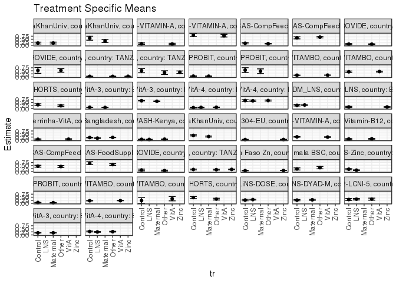

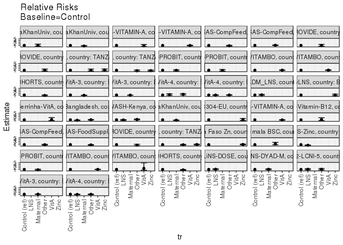

[figure not shown]

[figure not shown]

## Results Table

### Parameter: TSM

| agecat | studyid | country | intXenstunt | intervention_level | baseline_level | estimate | ci_lower | ci_upper |
| --- | --- | --- | --- | --- | --- | --- | --- | --- |
| 0-6 months | ki1000125-AgaKhanUniv | PAKISTAN | 0_0-6 months | Control | NA | 0.1844660 | 0.1093780 | 0.2595540 |
| 0-6 months | ki1000125-AgaKhanUniv | PAKISTAN | 0_0-6 months | Maternal | NA | 0.1862745 | 0.1105345 | 0.2620145 |
| 0-6 months | ki1000125-AgaKhanUniv | PAKISTAN | 1_0-6 months | Control | NA | 0.5833333 | 0.4213538 | 0.7453128 |
| 0-6 months | ki1000125-AgaKhanUniv | PAKISTAN | 1_0-6 months | Maternal | NA | 0.3529412 | 0.2210255 | 0.4848569 |
| 0-6 months | ki1000304-VITAMIN-A | INDIA | 0_0-6 months | Control | NA | 0.1395349 | 0.0796149 | 0.1994549 |
| 0-6 months | ki1000304-VITAMIN-A | INDIA | 0_0-6 months | VitA | NA | 0.1090909 | 0.0507097 | 0.1674721 |
| 0-6 months | ki1000304-VITAMIN-A | INDIA | 1_0-6 months | Control | NA | 0.8333333 | 0.7200268 | 0.9466399 |
| 0-6 months | ki1000304-VITAMIN-A | INDIA | 1_0-6 months | VitA | NA | 0.7924528 | 0.6826905 | 0.9022151 |
| 0-6 months | ki1000304b-SAS-CompFeed | INDIA | 0_0-6 months | Control | NA | 0.1678832 | 0.1195413 | 0.2162251 |
| 0-6 months | ki1000304b-SAS-CompFeed | INDIA | 0_0-6 months | Other | NA | 0.1335505 | 0.1087871 | 0.1583139 |
| 0-6 months | ki1000304b-SAS-CompFeed | INDIA | 1_0-6 months | Control | NA | 0.6129032 | 0.5265160 | 0.6992905 |
| 0-6 months | ki1000304b-SAS-CompFeed | INDIA | 1_0-6 months | Other | NA | 0.6694915 | 0.6046052 | 0.7343779 |
| 0-6 months | ki1017093b-PROVIDE | BANGLADESH | 0_0-6 months | Control | NA | 0.1006711 | 0.0523160 | 0.1490263 |
| 0-6 months | ki1017093b-PROVIDE | BANGLADESH | 0_0-6 months | Other | NA | 0.0955711 | 0.0677262 | 0.1234160 |
| 0-6 months | ki1017093b-PROVIDE | BANGLADESH | 1_0-6 months | Control | NA | 0.5294118 | 0.2902059 | 0.7686177 |
| 0-6 months | ki1017093b-PROVIDE | BANGLADESH | 1_0-6 months | Other | NA | 0.5333333 | 0.3863813 | 0.6802853 |
| 0-6 months | ki1066203-TanzaniaChild2 | TANZANIA, UNITED REPUBLIC OF | 0_0-6 months | Control | NA | 0.0456274 | 0.0277900 | 0.0634648 |
| 0-6 months | ki1066203-TanzaniaChild2 | TANZANIA, UNITED REPUBLIC OF | 0_0-6 months | Other | NA | 0.0444015 | 0.0266587 | 0.0621444 |
| 0-6 months | ki1066203-TanzaniaChild2 | TANZANIA, UNITED REPUBLIC OF | 0_0-6 months | Zinc | NA | 0.0499520 | 0.0367154 | 0.0631886 |
| 0-6 months | ki1066203-TanzaniaChild2 | TANZANIA, UNITED REPUBLIC OF | 1_0-6 months | Control | NA | 0.5161290 | 0.3396174 | 0.6926407 |
| 0-6 months | ki1066203-TanzaniaChild2 | TANZANIA, UNITED REPUBLIC OF | 1_0-6 months | Other | NA | 0.3513514 | 0.1970090 | 0.5056937 |
| 0-6 months | ki1066203-TanzaniaChild2 | TANZANIA, UNITED REPUBLIC OF | 1_0-6 months | Zinc | NA | 0.3827160 | 0.2765101 | 0.4889220 |
| 0-6 months | ki1119695-PROBIT | BELARUS | 0_0-6 months | Control | NA | 0.0643079 | 0.0454391 | 0.0831766 |
| 0-6 months | ki1119695-PROBIT | BELARUS | 0_0-6 months | Maternal | NA | 0.0583986 | 0.0441719 | 0.0726252 |
| 0-6 months | ki1119695-PROBIT | BELARUS | 1_0-6 months | Control | NA | 0.5555556 | 0.3547608 | 0.7563503 |
| 0-6 months | ki1119695-PROBIT | BELARUS | 1_0-6 months | Maternal | NA | 0.4657534 | 0.2721626 | 0.6593442 |
| 0-6 months | ki1126311-ZVITAMBO | ZIMBABWE | 0_0-6 months | Control | NA | 0.1399217 | 0.1248818 | 0.1549617 |
| 0-6 months | ki1126311-ZVITAMBO | ZIMBABWE | 0_0-6 months | VitA | NA | 0.1466688 | 0.1377969 | 0.1555408 |
| 0-6 months | ki1126311-ZVITAMBO | ZIMBABWE | 1_0-6 months | Control | NA | 0.4214876 | 0.3592407 | 0.4837346 |
| 0-6 months | ki1126311-ZVITAMBO | ZIMBABWE | 1_0-6 months | VitA | NA | 0.4398868 | 0.4032789 | 0.4764948 |

[output cut: 67 more lines]

### Parameter: E(Y)

| agecat | studyid | country | intXenstunt | intervention_level | baseline_level | estimate | ci_lower | ci_upper |
| --- | --- | --- | --- | --- | --- | --- | --- | --- |
| 0-6 months | ki1000125-AgaKhanUniv | PAKISTAN | 0_0-6 months | NA | NA | 0.1853659 | 0.1320411 | 0.2386906 |
| 0-6 months | ki1000125-AgaKhanUniv | PAKISTAN | 1_0-6 months | NA | NA | 0.4482759 | 0.3431686 | 0.5533831 |
| 0-6 months | ki1000304-VITAMIN-A | INDIA | 0_0-6 months | NA | NA | 0.1255230 | 0.0834314 | 0.1676146 |
| 0-6 months | ki1000304-VITAMIN-A | INDIA | 1_0-6 months | NA | NA | 0.8105263 | 0.7313050 | 0.8897477 |
| 0-6 months | ki1000304b-SAS-CompFeed | INDIA | 0_0-6 months | NA | NA | 0.1497418 | 0.1204064 | 0.1790773 |
| 0-6 months | ki1000304b-SAS-CompFeed | INDIA | 1_0-6 months | NA | NA | 0.6445498 | 0.5879030 | 0.7011965 |
| 0-6 months | ki1017093b-PROVIDE | BANGLADESH | 0_0-6 months | NA | NA | 0.0968858 | 0.0727500 | 0.1210216 |
| 0-6 months | ki1017093b-PROVIDE | BANGLADESH | 1_0-6 months | NA | NA | 0.5322581 | 0.4070456 | 0.6574705 |
| 0-6 months | ki1066203-TanzaniaChild2 | TANZANIA, UNITED REPUBLIC OF | 0_0-6 months | NA | NA | 0.0474820 | 0.0383514 | 0.0566126 |
| 0-6 months | ki1066203-TanzaniaChild2 | TANZANIA, UNITED REPUBLIC OF | 1_0-6 months | NA | NA | 0.4026846 | 0.3236710 | 0.4816981 |
| 0-6 months | ki1119695-PROBIT | BELARUS | 0_0-6 months | NA | NA | 0.0612499 | 0.0493461 | 0.0731537 |
| 0-6 months | ki1119695-PROBIT | BELARUS | 1_0-6 months | NA | NA | 0.5073529 | 0.3671357 | 0.6475702 |
| 0-6 months | ki1126311-ZVITAMBO | ZIMBABWE | 0_0-6 months | NA | NA | 0.1449773 | 0.1373345 | 0.1526202 |
| 0-6 months | ki1126311-ZVITAMBO | ZIMBABWE | 1_0-6 months | NA | NA | 0.4351949 | 0.4036351 | 0.4667548 |
| 0-6 months | ki1135781-COHORTS | GUATEMALA | 0_0-6 months | NA | NA | 0.2671480 | 0.2149472 | 0.3193489 |
| 0-6 months | kiGH5241-JiVitA-3 | BANGLADESH | 0_0-6 months | NA | NA | 0.0957002 | 0.0901349 | 0.1012655 |
| 0-6 months | kiGH5241-JiVitA-3 | BANGLADESH | 1_0-6 months | NA | NA | 0.6159651 | 0.6012441 | 0.6306861 |
| 0-6 months | kiGH5241-JiVitA-4 | BANGLADESH | 0_0-6 months | NA | NA | 0.0921376 | 0.0801323 | 0.1041429 |
| 0-6 months | kiGH5241-JiVitA-4 | BANGLADESH | 1_0-6 months | NA | NA | 0.6486280 | 0.6177594 | 0.6794967 |
| 6-24 months | iLiNS_DYADM_LNS | MALAWI | 0_6-24 months | NA | NA | 0.2760736 | 0.2363437 | 0.3158036 |
| 6-24 months | iLiNS-Zinc_ZvLNS | BURKINA FASO | 0_6-24 months | NA | NA | 0.1275591 | 0.1008297 | 0.1542884 |
| 6-24 months | ki1000107-Serrinha-VitA | BRAZIL | 0_6-24 months | NA | NA | 0.0720000 | 0.0458029 | 0.0981971 |
| 6-24 months | ki1000110-WASH-Bangladesh | BANGLADESH | 0_6-24 months | NA | NA | 0.2045699 | 0.1916054 | 0.2175344 |
| 6-24 months | ki1000111-WASH-Kenya | KENYA | 0_6-24 months | NA | NA | 0.0674731 | 0.0607135 | 0.0742326 |
| 6-24 months | ki1000125-AgaKhanUniv | PAKISTAN | 0_6-24 months | NA | NA | 0.3395400 | 0.3088060 | 0.3702740 |
| 6-24 months | ki1000304-EU | INDIA | 0_6-24 months | NA | NA | 0.0496454 | 0.0369640 | 0.0623268 |
| 6-24 months | ki1000304-VITAMIN-A | INDIA | 0_6-24 months | NA | NA | 0.2584867 | 0.2411297 | 0.2758438 |
| 6-24 months | ki1000304-Vitamin-B12 | INDIA | 0_6-24 months | NA | NA | 0.1054852 | 0.0778026 | 0.1331678 |
| 6-24 months | ki1000304b-SAS-CompFeed | INDIA | 0_6-24 months | NA | NA | 0.4370016 | 0.3770013 | 0.4970019 |
| 6-24 months | ki1000304b-SAS-FoodSuppl | INDIA | 0_6-24 months | NA | NA | 0.6141079 | 0.5525196 | 0.6756961 |
| 6-24 months | ki1017093b-PROVIDE | BANGLADESH | 0_6-24 months | NA | NA | 0.1081871 | 0.0752189 | 0.1411554 |
| 6-24 months | ki1066203-TanzaniaChild2 | TANZANIA, UNITED REPUBLIC OF | 0_6-24 months | NA | NA | 0.1829268 | 0.1650817 | 0.2007719 |
| 6-24 months | ki1112895-Burkina Faso Zn | BURKINA FASO | 0_6-24 months | NA | NA | 0.0987984 | 0.0907207 | 0.1068761 |
| 6-24 months | ki1112895-Guatemala BSC | GUATEMALA | 0_6-24 months | NA | NA | 0.2808989 | 0.2146877 | 0.3471101 |
| 6-24 months | ki1112895-iLiNS-Zinc | BURKINA FASO | 0_6-24 months | NA | NA | 0.1472562 | 0.1218922 | 0.1726202 |
| 6-24 months | ki1119695-PROBIT | BELARUS | 0_6-24 months | NA | NA | 0.0593453 | 0.0475288 | 0.0711618 |
| 6-24 months | ki1126311-ZVITAMBO | ZIMBABWE | 0_6-24 months | NA | NA | 0.2165910 | 0.2077636 | 0.2254183 |
| 6-24 months | ki1126311-ZVITAMBO | ZIMBABWE | 1_6-24 months | NA | NA | 0.3333333 | 0.1890388 | 0.4776279 |
| 6-24 months | ki1135781-COHORTS | GUATEMALA | 0_6-24 months | NA | NA | 0.3993289 | 0.3436291 | 0.4550287 |
| 6-24 months | ki1148112-iLiNS-DOSE | MALAWI | 0_6-24 months | NA | NA | 0.2985437 | 0.2730214 | 0.3240659 |
| 6-24 months | ki1148112-iLiNS-DYAD-M | MALAWI | 0_6-24 months | NA | NA | 0.2797858 | 0.2475387 | 0.3120330 |
| 6-24 months | ki1148112-LCNI-5 | MALAWI | 0_6-24 months | NA | NA | 0.3320463 | 0.2914511 | 0.3726416 |
| 6-24 months | kiGH5241-JiVitA-3 | BANGLADESH | 0_6-24 months | NA | NA | 0.1718662 | 0.1623121 | 0.1814203 |
| 6-24 months | kiGH5241-JiVitA-4 | BANGLADESH | 0_6-24 months | NA | NA | 0.2626468 | 0.2444010 | 0.2808926 |

### Parameter: RR

| agecat | studyid | country | intXenstunt | intervention_level | baseline_level | estimate | ci_lower | ci_upper |
| --- | --- | --- | --- | --- | --- | --- | --- | --- |
| 0-6 months | ki1000125-AgaKhanUniv | PAKISTAN | 0_0-6 months | Control | Control | 1.0000000 | 1.0000000 | 1.0000000 |
| 0-6 months | ki1000125-AgaKhanUniv | PAKISTAN | 0_0-6 months | Maternal | Control | 1.0098039 | 0.5680256 | 1.7951724 |
| 0-6 months | ki1000125-AgaKhanUniv | PAKISTAN | 1_0-6 months | Control | Control | 1.0000000 | 1.0000000 | 1.0000000 |
| 0-6 months | ki1000125-AgaKhanUniv | PAKISTAN | 1_0-6 months | Maternal | Control | 0.6050420 | 0.3798121 | 0.9638340 |
| 0-6 months | ki1000304-VITAMIN-A | INDIA | 0_0-6 months | Control | Control | 1.0000000 | 1.0000000 | 1.0000000 |
| 0-6 months | ki1000304-VITAMIN-A | INDIA | 0_0-6 months | VitA | Control | 0.7818182 | 0.3936531 | 1.5527368 |
| 0-6 months | ki1000304-VITAMIN-A | INDIA | 1_0-6 months | Control | Control | 1.0000000 | 1.0000000 | 1.0000000 |
| 0-6 months | ki1000304-VITAMIN-A | INDIA | 1_0-6 months | VitA | Control | 0.9509434 | 0.7831791 | 1.1546444 |
| 0-6 months | ki1000304b-SAS-CompFeed | INDIA | 0_0-6 months | Control | Control | 1.0000000 | 1.0000000 | 1.0000000 |
| 0-6 months | ki1000304b-SAS-CompFeed | INDIA | 0_0-6 months | Other | Control | 0.7954964 | 0.5644536 | 1.1211099 |
| 0-6 months | ki1000304b-SAS-CompFeed | INDIA | 1_0-6 months | Control | Control | 1.0000000 | 1.0000000 | 1.0000000 |
| 0-6 months | ki1000304b-SAS-CompFeed | INDIA | 1_0-6 months | Other | Control | 1.0923283 | 0.9203708 | 1.2964134 |
| 0-6 months | ki1017093b-PROVIDE | BANGLADESH | 0_0-6 months | Control | Control | 1.0000000 | 1.0000000 | 1.0000000 |
| 0-6 months | ki1017093b-PROVIDE | BANGLADESH | 0_0-6 months | Other | Control | 0.9493395 | 0.5413048 | 1.6649504 |
| 0-6 months | ki1017093b-PROVIDE | BANGLADESH | 1_0-6 months | Control | Control | 1.0000000 | 1.0000000 | 1.0000000 |
| 0-6 months | ki1017093b-PROVIDE | BANGLADESH | 1_0-6 months | Other | Control | 1.0074074 | 0.5934282 | 1.7101811 |
| 0-6 months | ki1066203-TanzaniaChild2 | TANZANIA, UNITED REPUBLIC OF | 0_0-6 months | Control | Control | 1.0000000 | 1.0000000 | 1.0000000 |
| 0-6 months | ki1066203-TanzaniaChild2 | TANZANIA, UNITED REPUBLIC OF | 0_0-6 months | Other | Control | 0.9731339 | 0.5564038 | 1.7019823 |
| 0-6 months | ki1066203-TanzaniaChild2 | TANZANIA, UNITED REPUBLIC OF | 0_0-6 months | Zinc | Control | 1.0947806 | 0.6826819 | 1.7556414 |
| 0-6 months | ki1066203-TanzaniaChild2 | TANZANIA, UNITED REPUBLIC OF | 1_0-6 months | Control | Control | 1.0000000 | 1.0000000 | 1.0000000 |
| 0-6 months | ki1066203-TanzaniaChild2 | TANZANIA, UNITED REPUBLIC OF | 1_0-6 months | Other | Control | 0.6807432 | 0.3901278 | 1.1878449 |
| 0-6 months | ki1066203-TanzaniaChild2 | TANZANIA, UNITED REPUBLIC OF | 1_0-6 months | Zinc | Control | 0.7415123 | 0.4773616 | 1.1518323 |
| 0-6 months | ki1119695-PROBIT | BELARUS | 0_0-6 months | Control | Control | 1.0000000 | 1.0000000 | 1.0000000 |
| 0-6 months | ki1119695-PROBIT | BELARUS | 0_0-6 months | Maternal | Control | 0.9081093 | 0.6207356 | 1.3285245 |
| 0-6 months | ki1119695-PROBIT | BELARUS | 1_0-6 months | Control | Control | 1.0000000 | 1.0000000 | 1.0000000 |
| 0-6 months | ki1119695-PROBIT | BELARUS | 1_0-6 months | Maternal | Control | 0.8383562 | 0.4832867 | 1.4542942 |
| 0-6 months | ki1126311-ZVITAMBO | ZIMBABWE | 0_0-6 months | Control | Control | 1.0000000 | 1.0000000 | 1.0000000 |
| 0-6 months | ki1126311-ZVITAMBO | ZIMBABWE | 0_0-6 months | VitA | Control | 1.0482207 | 0.9265887 | 1.1858192 |
| 0-6 months | ki1126311-ZVITAMBO | ZIMBABWE | 1_0-6 months | Control | Control | 1.0000000 | 1.0000000 | 1.0000000 |
| 0-6 months | ki1126311-ZVITAMBO | ZIMBABWE | 1_0-6 months | VitA | Control | 1.0436531 | 0.8809179 | 1.2364509 |

[output cut: 67 more lines]

### Parameter: PAR

| agecat | studyid | country | intXenstunt | intervention_level | baseline_level | estimate | ci_lower | ci_upper |
| --- | --- | --- | --- | --- | --- | --- | --- | --- |
| 0-6 months | ki1000125-AgaKhanUniv | PAKISTAN | 0_0-6 months | Control | NA | 0.0008998 | -0.0521664 | 0.0539661 |
| 0-6 months | ki1000125-AgaKhanUniv | PAKISTAN | 1_0-6 months | Control | NA | -0.1350575 | -0.2598421 | -0.0102728 |
| 0-6 months | ki1000304-VITAMIN-A | INDIA | 0_0-6 months | Control | NA | -0.0140119 | -0.0525641 | 0.0245403 |
| 0-6 months | ki1000304-VITAMIN-A | INDIA | 1_0-6 months | Control | NA | -0.0228070 | -0.1109125 | 0.0652984 |
| 0-6 months | ki1000304b-SAS-CompFeed | INDIA | 0_0-6 months | Control | NA | -0.0181414 | -0.0505040 | 0.0142213 |
| 0-6 months | ki1000304b-SAS-CompFeed | INDIA | 1_0-6 months | Control | NA | 0.0316465 | -0.0308536 | 0.0941467 |
| 0-6 months | ki1017093b-PROVIDE | BANGLADESH | 0_0-6 months | Control | NA | -0.0037853 | -0.0452008 | 0.0376301 |
| 0-6 months | ki1017093b-PROVIDE | BANGLADESH | 1_0-6 months | Control | NA | 0.0028463 | -0.2009163 | 0.2066089 |
| 0-6 months | ki1066203-TanzaniaChild2 | TANZANIA, UNITED REPUBLIC OF | 0_0-6 months | Control | NA | 0.0018546 | -0.0136697 | 0.0173790 |
| 0-6 months | ki1066203-TanzaniaChild2 | TANZANIA, UNITED REPUBLIC OF | 1_0-6 months | Control | NA | -0.1134445 | -0.2697618 | 0.0428729 |
| 0-6 months | ki1119695-PROBIT | BELARUS | 0_0-6 months | Control | NA | -0.0030579 | -0.0152347 | 0.0091188 |
| 0-6 months | ki1119695-PROBIT | BELARUS | 1_0-6 months | Control | NA | -0.0482026 | -0.1995478 | 0.1031426 |
| 0-6 months | ki1126311-ZVITAMBO | ZIMBABWE | 0_0-6 months | Control | NA | 0.0050556 | -0.0080285 | 0.0181397 |
| 0-6 months | ki1126311-ZVITAMBO | ZIMBABWE | 1_0-6 months | Control | NA | 0.0137073 | -0.0400940 | 0.0675086 |
| 0-6 months | ki1135781-COHORTS | GUATEMALA | 0_0-6 months | Control | NA | -0.0434580 | -0.0983984 | 0.0114824 |
| 0-6 months | kiGH5241-JiVitA-3 | BANGLADESH | 0_0-6 months | Control | NA | -0.0092143 | -0.0149954 | -0.0034332 |
| 0-6 months | kiGH5241-JiVitA-3 | BANGLADESH | 1_0-6 months | Control | NA | -0.0205740 | -0.0347972 | -0.0063508 |
| 0-6 months | kiGH5241-JiVitA-4 | BANGLADESH | 0_0-6 months | Control | NA | 0.0175455 | -0.0002441 | 0.0353351 |
| 0-6 months | kiGH5241-JiVitA-4 | BANGLADESH | 1_0-6 months | Control | NA | -0.0046227 | -0.0613352 | 0.0520897 |
| 6-24 months | iLiNS_DYADM_LNS | MALAWI | 0_6-24 months | Control | NA | 0.0133285 | -0.0247815 | 0.0514386 |
| 6-24 months | iLiNS-Zinc_ZvLNS | BURKINA FASO | 0_6-24 months | Control | NA | -0.0011329 | -0.0459807 | 0.0437149 |
| 6-24 months | ki1000107-Serrinha-VitA | BRAZIL | 0_6-24 months | Control | NA | 0.0046425 | -0.0208430 | 0.0301280 |
| 6-24 months | ki1000110-WASH-Bangladesh | BANGLADESH | 0_6-24 months | Control | NA | -0.0096365 | -0.0328355 | 0.0135624 |
| 6-24 months | ki1000111-WASH-Kenya | KENYA | 0_6-24 months | Control | NA | 0.0040773 | -0.0051542 | 0.0133087 |
| 6-24 months | ki1000125-AgaKhanUniv | PAKISTAN | 0_6-24 months | Control | NA | -0.0464645 | -0.0781730 | -0.0147561 |
| 6-24 months | ki1000304-EU | INDIA | 0_6-24 months | Control | NA | 0.0025439 | -0.0103971 | 0.0154850 |
| 6-24 months | ki1000304-VITAMIN-A | INDIA | 0_6-24 months | Control | NA | -0.0085076 | -0.0258864 | 0.0088713 |
| 6-24 months | ki1000304-Vitamin-B12 | INDIA | 0_6-24 months | Control | NA | 0.0137421 | -0.0347936 | 0.0622778 |
| 6-24 months | ki1000304b-SAS-CompFeed | INDIA | 0_6-24 months | Control | NA | -0.0138459 | -0.0766176 | 0.0489259 |
| 6-24 months | ki1000304b-SAS-FoodSuppl | INDIA | 0_6-24 months | Control | NA | -0.0858921 | -0.1887108 | 0.0169266 |
| 6-24 months | ki1017093b-PROVIDE | BANGLADESH | 0_6-24 months | Control | NA | -0.0346700 | -0.0939343 | 0.0245943 |
| 6-24 months | ki1066203-TanzaniaChild2 | TANZANIA, UNITED REPUBLIC OF | 0_6-24 months | Control | NA | 0.0001074 | -0.0306601 | 0.0308750 |
| 6-24 months | ki1112895-Burkina Faso Zn | BURKINA FASO | 0_6-24 months | Control | NA | 0.0073157 | -0.0093943 | 0.0240258 |
| 6-24 months | ki1112895-Guatemala BSC | GUATEMALA | 0_6-24 months | Control | NA | 0.0526380 | -0.0116627 | 0.1169387 |
| 6-24 months | ki1112895-iLiNS-Zinc | BURKINA FASO | 0_6-24 months | Control | NA | -0.0597502 | -0.1042019 | -0.0152984 |
| 6-24 months | ki1119695-PROBIT | BELARUS | 0_6-24 months | Control | NA | -0.0077768 | -0.0196929 | 0.0041394 |
| 6-24 months | ki1126311-ZVITAMBO | ZIMBABWE | 0_6-24 months | Control | NA | 0.0038654 | -0.0112878 | 0.0190187 |
| 6-24 months | ki1126311-ZVITAMBO | ZIMBABWE | 1_6-24 months | Control | NA | 0.1025641 | -0.1006382 | 0.3057664 |
| 6-24 months | ki1135781-COHORTS | GUATEMALA | 0_6-24 months | Control | NA | -0.0731121 | -0.1380686 | -0.0081556 |
| 6-24 months | ki1148112-iLiNS-DOSE | MALAWI | 0_6-24 months | Control | NA | 0.0298870 | -0.0265684 | 0.0863423 |
| 6-24 months | ki1148112-iLiNS-DYAD-M | MALAWI | 0_6-24 months | Control | NA | 0.0170407 | -0.0273378 | 0.0614192 |
| 6-24 months | ki1148112-LCNI-5 | MALAWI | 0_6-24 months | Control | NA | 0.0214403 | -0.0471858 | 0.0900663 |
| 6-24 months | kiGH5241-JiVitA-3 | BANGLADESH | 0_6-24 months | Control | NA | 0.0018488 | -0.0080316 | 0.0117292 |
| 6-24 months | kiGH5241-JiVitA-4 | BANGLADESH | 0_6-24 months | Control | NA | -0.0162608 | -0.0472753 | 0.0147537 |

### Parameter: PAF

| agecat | studyid | country | intXenstunt | intervention_level | baseline_level | estimate | ci_lower | ci_upper |
| --- | --- | --- | --- | --- | --- | --- | --- | --- |
| 0-6 months | ki1000125-AgaKhanUniv | PAKISTAN | 0_0-6 months | Control | NA | 0.0048544 | -0.3268491 | 0.2536342 |
| 0-6 months | ki1000125-AgaKhanUniv | PAKISTAN | 1_0-6 months | Control | NA | -0.3012821 | -0.6238679 | -0.0427788 |
| 0-6 months | ki1000304-VITAMIN-A | INDIA | 0_0-6 months | Control | NA | -0.1116279 | -0.4633316 | 0.1555457 |
| 0-6 months | ki1000304-VITAMIN-A | INDIA | 1_0-6 months | Control | NA | -0.0281385 | -0.1430955 | 0.0752577 |
| 0-6 months | ki1000304b-SAS-CompFeed | INDIA | 0_0-6 months | Control | NA | -0.1211511 | -0.3545498 | 0.0720313 |
| 0-6 months | ki1000304b-SAS-CompFeed | INDIA | 1_0-6 months | Control | NA | 0.0490987 | -0.0533253 | 0.1415631 |
| 0-6 months | ki1017093b-PROVIDE | BANGLADESH | 0_0-6 months | Control | NA | -0.0390700 | -0.5677423 | 0.3113240 |
| 0-6 months | ki1017093b-PROVIDE | BANGLADESH | 1_0-6 months | Control | NA | 0.0053476 | -0.4615911 | 0.3231120 |
| 0-6 months | ki1066203-TanzaniaChild2 | TANZANIA, UNITED REPUBLIC OF | 0_0-6 months | Control | NA | 0.0390598 | -0.3502870 | 0.3161409 |
| 0-6 months | ki1066203-TanzaniaChild2 | TANZANIA, UNITED REPUBLIC OF | 1_0-6 months | Control | NA | -0.2817204 | -0.7389752 | 0.0553015 |
| 0-6 months | ki1119695-PROBIT | BELARUS | 0_0-6 months | Control | NA | -0.0499254 | -0.2664025 | 0.1295473 |
| 0-6 months | ki1119695-PROBIT | BELARUS | 1_0-6 months | Control | NA | -0.0950081 | -0.4412324 | 0.1680435 |
| 0-6 months | ki1126311-ZVITAMBO | ZIMBABWE | 0_0-6 months | Control | NA | 0.0348716 | -0.0597182 | 0.1210183 |
| 0-6 months | ki1126311-ZVITAMBO | ZIMBABWE | 1_0-6 months | Control | NA | 0.0314970 | -0.1003774 | 0.1475670 |
| 0-6 months | ki1135781-COHORTS | GUATEMALA | 0_0-6 months | Control | NA | -0.1626740 | -0.3871922 | 0.0255057 |
| 0-6 months | kiGH5241-JiVitA-3 | BANGLADESH | 0_0-6 months | Control | NA | -0.0962828 | -0.1576271 | -0.0381893 |
| 0-6 months | kiGH5241-JiVitA-3 | BANGLADESH | 1_0-6 months | Control | NA | -0.0334012 | -0.0568679 | -0.0104555 |
| 0-6 months | kiGH5241-JiVitA-4 | BANGLADESH | 0_0-6 months | Control | NA | 0.1904274 | -0.0225240 | 0.3590294 |
| 0-6 months | kiGH5241-JiVitA-4 | BANGLADESH | 1_0-6 months | Control | NA | -0.0071269 | -0.0984390 | 0.0765945 |
| 6-24 months | iLiNS_DYADM_LNS | MALAWI | 0_6-24 months | Control | NA | 0.0482789 | -0.1002286 | 0.1767410 |
| 6-24 months | iLiNS-Zinc_ZvLNS | BURKINA FASO | 0_6-24 months | Control | NA | -0.0088816 | -0.4295778 | 0.2880121 |
| 6-24 months | ki1000107-Serrinha-VitA | BRAZIL | 0_6-24 months | Control | NA | 0.0644790 | -0.3647875 | 0.3587283 |
| 6-24 months | ki1000110-WASH-Bangladesh | BANGLADESH | 0_6-24 months | Control | NA | -0.0471064 | -0.1668586 | 0.0603559 |
| 6-24 months | ki1000111-WASH-Kenya | KENYA | 0_6-24 months | Control | NA | 0.0604279 | -0.0867181 | 0.1876498 |
| 6-24 months | ki1000125-AgaKhanUniv | PAKISTAN | 0_6-24 months | Control | NA | -0.1368456 | -0.2343253 | -0.0470641 |
| 6-24 months | ki1000304-EU | INDIA | 0_6-24 months | Control | NA | 0.0512422 | -0.2483643 | 0.2789434 |
| 6-24 months | ki1000304-VITAMIN-A | INDIA | 0_6-24 months | Control | NA | -0.0329129 | -0.1023714 | 0.0321690 |
| 6-24 months | ki1000304-Vitamin-B12 | INDIA | 0_6-24 months | Control | NA | 0.1302752 | -0.4744706 | 0.4869879 |
| 6-24 months | ki1000304b-SAS-CompFeed | INDIA | 0_6-24 months | Control | NA | -0.0316838 | -0.1869179 | 0.1032477 |
| 6-24 months | ki1000304b-SAS-FoodSuppl | INDIA | 0_6-24 months | Control | NA | -0.1398649 | -0.3219951 | 0.0171734 |
| 6-24 months | ki1017093b-PROVIDE | BANGLADESH | 0_6-24 months | Control | NA | -0.3204633 | -0.9903855 | 0.1239771 |
| 6-24 months | ki1066203-TanzaniaChild2 | TANZANIA, UNITED REPUBLIC OF | 0_6-24 months | Control | NA | 0.0005874 | -0.1825902 | 0.1553916 |
| 6-24 months | ki1112895-Burkina Faso Zn | BURKINA FASO | 0_6-24 months | Control | NA | 0.0740472 | -0.1114137 | 0.2285603 |
| 6-24 months | ki1112895-Guatemala BSC | GUATEMALA | 0_6-24 months | Control | NA | 0.1873913 | -0.0749470 | 0.3857066 |
| 6-24 months | ki1112895-iLiNS-Zinc | BURKINA FASO | 0_6-24 months | Control | NA | -0.4057564 | -0.7685279 | -0.1173989 |
| 6-24 months | ki1119695-PROBIT | BELARUS | 0_6-24 months | Control | NA | -0.1310427 | -0.3428242 | 0.0473381 |
| 6-24 months | ki1126311-ZVITAMBO | ZIMBABWE | 0_6-24 months | Control | NA | 0.0178466 | -0.0546662 | 0.0853739 |
| 6-24 months | ki1126311-ZVITAMBO | ZIMBABWE | 1_6-24 months | Control | NA | 0.3076923 | -0.6591867 | 0.7111296 |
| 6-24 months | ki1135781-COHORTS | GUATEMALA | 0_6-24 months | Control | NA | -0.1830874 | -0.3587788 | -0.0301131 |
| 6-24 months | ki1148112-iLiNS-DOSE | MALAWI | 0_6-24 months | Control | NA | 0.1001092 | -0.1102742 | 0.2706275 |
| 6-24 months | ki1148112-iLiNS-DYAD-M | MALAWI | 0_6-24 months | Control | NA | 0.0609063 | -0.1118454 | 0.2068169 |
| 6-24 months | ki1148112-LCNI-5 | MALAWI | 0_6-24 months | Control | NA | 0.0645701 | -0.1667033 | 0.2499986 |
| 6-24 months | kiGH5241-JiVitA-3 | BANGLADESH | 0_6-24 months | Control | NA | 0.0107570 | -0.0484939 | 0.0666596 |
| 6-24 months | kiGH5241-JiVitA-4 | BANGLADESH | 0_6-24 months | Control | NA | -0.0619112 | -0.1866094 | 0.0496827 |